# Global Burden of Disease

2023-08-16

Data source: https://vizhub.healthdata.org/gbd-results/

# Modeling the global burden of infectious Diseases

Objectives: I defined some objectives of the analysis a priori in “20230815_globalHealth.docx” At this point I would generally state the objective as: Can we find some factors/interventions associated with certain diseases/countries that could be applied to other diseases/countries to lower death rates, or that need to be avoided in other diseases/countries to avoid rising death rates? These factors would not necessarily be within the GBD data. For example, I might find that disease X decreased in countries A,B,C from year 19XX, but remained stable in countries D,E. I could then try to research what happened in A,B,C, but not D,E around this time. [Another simple question to start off with would be: Which disease has a high death rate but also examples (e.g. certain countries, age groups, sex) where it has already declined a lot.]

Change log: In the first version some locations were represented by multiple ‘regions’; here I use data in which only one classification of 21 mutually exclusive regions is used

## Clean and load libraries

```
## Linked to JAGS 4.3.1
```

```
## Loaded modules: basemod,bugs
```

[output not shown]

## Data import and cleaning

Obtain a file that contains all years only for “Tuberculosis”,“HIV/AIDS”,“Zika virus”

```r
allTime_HTZ_Deaths= read.csv('./20230823_Deaths_HTZ_21reg_MF_5year/IHME-GBD_2019_DATA-afd4b08e-1.csv',stringsAsFactors = TRUE)   #HTZ= "Tuberculosis","HIV/AIDS","Zika virus"
#limit to metric== 'Percent' and remove 'Number'
allTime_HTZ_Deaths= allTime_HTZ_Deaths[allTime_HTZ_Deaths$metric=='Percent',]

allTime_HTZ_PrevInci= read.csv('./20230907_PrevInci_HTZ_21reg_MF_5year/IHME-GBD_2019_DATA-cacc055a-1.csv',stringsAsFactors = TRUE)

allTime_HTZ= rbind.data.frame(allTime_HTZ_Deaths,allTime_HTZ_PrevInci)
```

Check data for completeness

```r
unique(allTime_HTZ$age)
```

```
##  [1] 95+ years   0-6 days    7-27 days   28-364 days 1-4 years   5-9 years
##  [7] 10-14 years 15-19 years 20-24 years 25-29 years 30-34 years 35-39 years
## [13] 40-44 years 45-49 years 50-54 years 55-59 years 60-64 years 65-69 years
## [19] 70-74 years 75-79 years 80-84       85-89       90-94
## 23 Levels: 0-6 days 1-4 years 10-14 years 15-19 years ... 95+ years
```

This indicates entry “80-84” instead of “80-84 years” and two other such cases

```
##  [1] "0-6 days"    "1-4 years"   "10-14 years" "15-19 years" "20-24 years"
##  [6] "25-29 years" "28-364 days" "30-34 years" "35-39 years" "40-44 years"
## [11] "45-49 years" "5-9 years"   "50-54 years" "55-59 years" "60-64 years"
## [16] "65-69 years" "7-27 days"   "70-74 years" "75-79 years" "80-84 years"
## [21] "85-89 years" "90-94 years" "95+ years"
```

```
##  [1] 1-4 years   5-9 years   10-14 years 15-19 years 20-24 years 25-29 years
##  [7] 30-34 years 35-39 years 40-44 years 45-49 years 50-54 years 55-59 years
## [13] 60-64 years 65-69 years 70-74 years 75-79 years 80-84 years 85-89 years
## [19] 90-94 years
## 23 Levels: 0-6 days 1-4 years 10-14 years 15-19 years ... 95+ years
```

```
## [1] TRUE
```

```
## [1] 215460     10
```

```
## 'data.frame':    215460 obs. of  10 variables:
##  $ measure : Factor w/ 3 levels "Deaths","Incidence",..: 1 1 1 1 1 1 1 1 1 1 ...
##  $ location: Factor w/ 21 levels "Andean Latin America",..: 4 4 4 4 4 4 4 4 4 4 ...
##  $ sex     : Factor w/ 2 levels "Female","Male": 2 1 2 1 2 1 2 1 2 1 ...
##  $ age     : Factor w/ 23 levels "0-6 days","1-4 years",..: 2 2 12 12 3 3 4 4 5 5 ...
##  $ cause   : Factor w/ 3 levels "HIV/AIDS","Tuberculosis",..: 3 3 3 3 3 3 3 3 3 3 ...
##  $ metric  : Factor w/ 2 levels "Number","Percent": 2 2 2 2 2 2 2 2 2 2 ...
##  $ year    : int  1991 1991 1991 1991 1991 1991 1991 1991 1991 1991 ...
##  $ val     : num  0 0 0 0 0 0 0 0 0 0 ...
##  $ upper   : num  0 0 0 0 0 0 0 0 0 0 ...
##  $ lower   : num  0 0 0 0 0 0 0 0 0 0 ...
```

```r
head(allTime_HTZ)
```

|  | measure | location | sex | age | cause | metric | year | val | upper | lower |
| --- | --- | --- | --- | --- | --- | --- | --- | --- | --- | --- |
| 19 | Deaths | Central Asia | Male | 1-4 years | Zika virus | Percent | 1991 | 0 | 0 | 0 |
| 20 | Deaths | Central Asia | Female | 1-4 years | Zika virus | Percent | 1991 | 0 | 0 | 0 |
| 23 | Deaths | Central Asia | Male | 5-9 years | Zika virus | Percent | 1991 | 0 | 0 | 0 |
| 24 | Deaths | Central Asia | Female | 5-9 years | Zika virus | Percent | 1991 | 0 | 0 | 0 |
| 27 | Deaths | Central Asia | Male | 10-14 years | Zika virus | Percent | 1991 | 0 | 0 | 0 |
| 28 | Deaths | Central Asia | Female | 10-14 years | Zika virus | Percent | 1991 | 0 | 0 | 0 |

## Overview of death and prevalence rates

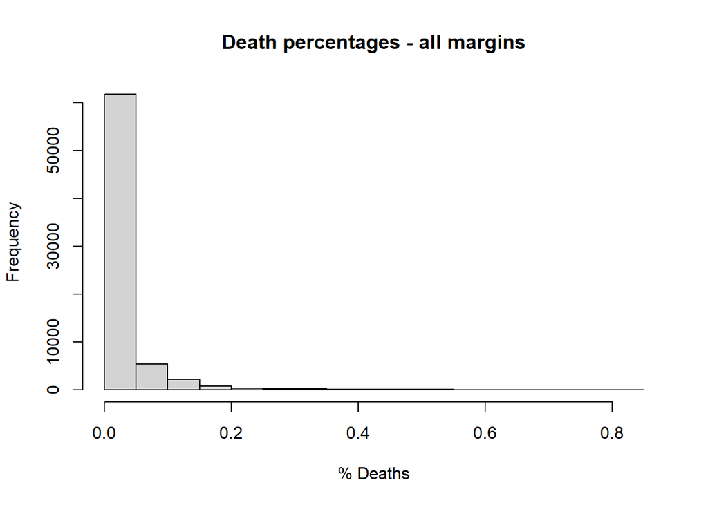

```r
hist(allTime_HTZ$val[allTime_HTZ$measure=='Deaths'],main='Death percentages - all margins',xlab='% Deaths')
```

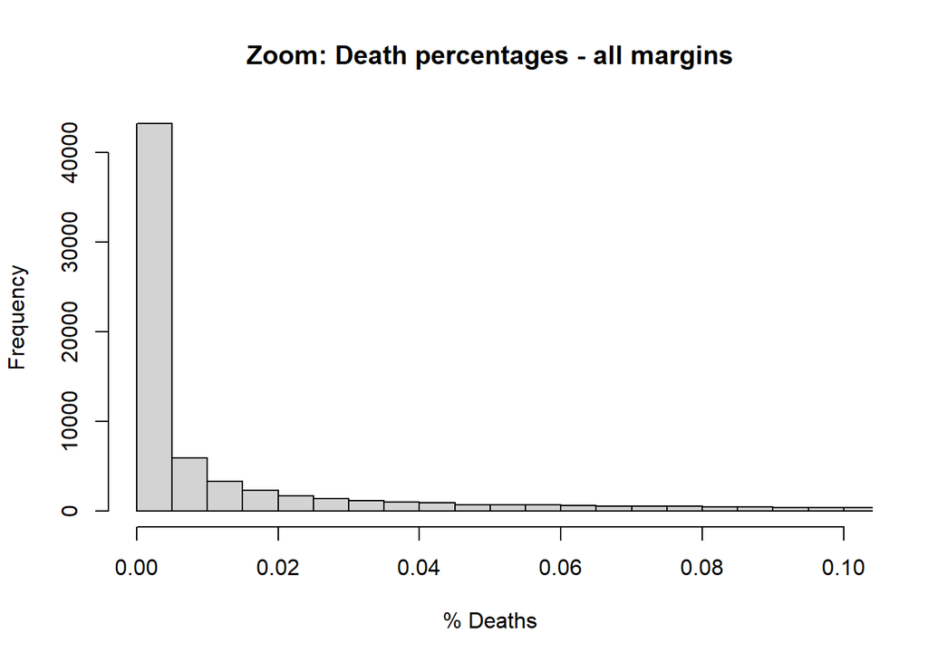

```r
hist(allTime_HTZ$val[allTime_HTZ$measure=='Deaths'],xlim=c(0,0.1),breaks= 200,main='Zoom: Death percentages - all margins',xlab='% Deaths')
```

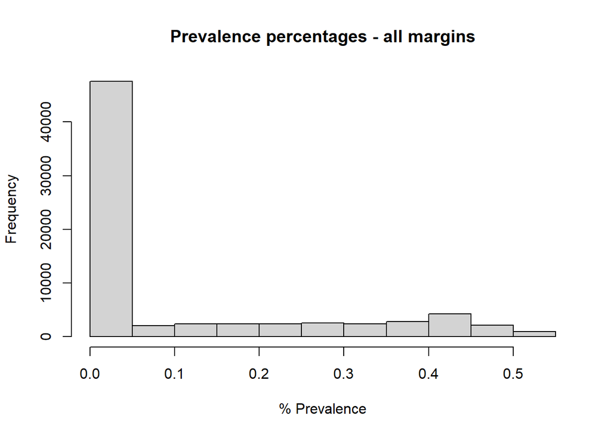

```r
hist(allTime_HTZ$val[allTime_HTZ$measure=='Prevalence'],main='Prevalence percentages - all margins',xlab='% Prevalence')
```

## Age- & sex- independent analysis

Simplify data: Average percentages over all age groups for location-cause-year combination

```r
allTime_HTZ_asi= data.frame( allTime_HTZ %>%   #asi= age-, sex- independent
  group_by(measure,location,cause,year) %>%
  summarize(val= mean(val),.groups='drop') )
head(allTime_HTZ_asi)
```

|  | measure | location | cause | year | val |
| --- | --- | --- | --- | --- | --- |
| 1 | Deaths | Andean Latin America | HIV/AIDS | 1990 | 0.004760393 |
| 2 | Deaths | Andean Latin America | HIV/AIDS | 1991 | 0.005558544 |
| 3 | Deaths | Andean Latin America | HIV/AIDS | 1992 | 0.006581146 |
| 4 | Deaths | Andean Latin America | HIV/AIDS | 1993 | 0.007625122 |
| 5 | Deaths | Andean Latin America | HIV/AIDS | 1994 | 0.008771679 |
| 6 | Deaths | Andean Latin America | HIV/AIDS | 1995 | 0.009228276 |

```r
dim(allTime_HTZ_asi)
```

```
## [1] 5670    5
```

Visualize death rates

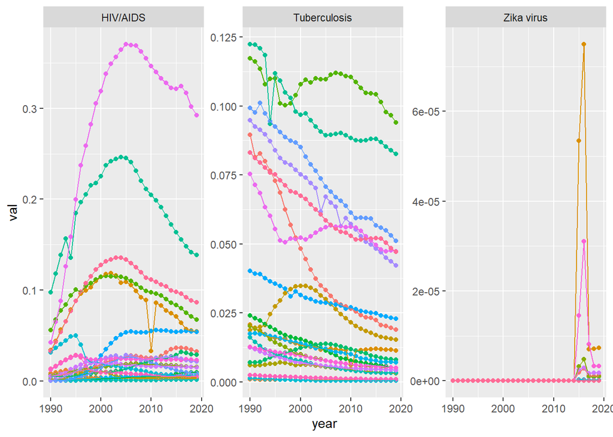

```r
allTime_HTZ_asi_D= allTime_HTZ_asi %>%
  filter(measure=='Deaths')

ggplot(data=allTime_HTZ_asi_D,mapping=aes(x=year,y=val,group=location,color=location))+
  geom_point()+
  geom_line()+
  facet_wrap(~cause,scales='free_y')+
  guides(color='none')
```

First impression: * For countries with highest HIV/AIDS death rates: HIV/AIDS death rates rises till about year 2000-2005, then steady decline * some HIV outliers that need to be investigated: data entry error or really some factor that lowered death rates * In most countries, tuberculosis is steadily declining, but in some there appears to be outbreak * Zika is only observed in recent years and has high death rates only in few locations

Are there locations that did not have any Zika case?

```r
allTime_HTZ_asi_D_sums= allTime_HTZ_asi_D %>%
  group_by(location,cause) %>%
  summarize(sumPerc= sum(val),.groups='drop')

allTime_HTZ_asi_D_sums[allTime_HTZ_asi_D_sums$sumPerc==0,]
```

| location | cause | sumPerc |
| --- | --- | --- |
| Australasia | Zika virus | 0 |
| Central Asia | Zika virus | 0 |
| Central Europe | Zika virus | 0 |
| Central Sub-Saharan Africa | Zika virus | 0 |
| East Asia | Zika virus | 0 |
| Eastern Europe | Zika virus | 0 |
| Eastern Sub-Saharan Africa | Zika virus | 0 |
| High-income Asia Pacific | Zika virus | 0 |
| North Africa and Middle East | Zika virus | 0 |
| Oceania | Zika virus | 0 |

[output cut: 5 more lines]

15 locations did not have any case of Zika

Normalize to max. percentages to get a clearer picture of dynamics in low incidence locations

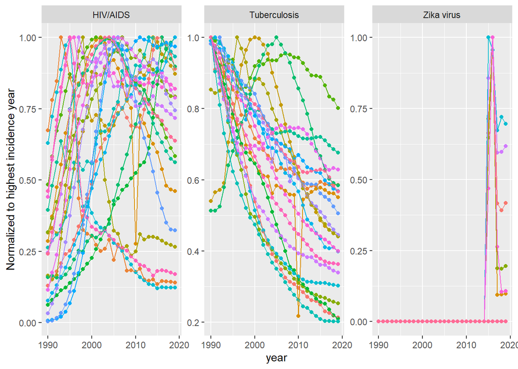

```r
allTime_HTZ_asi_D_norm= allTime_HTZ_asi_D %>%
  group_by(location,cause) %>%
  mutate(val_maxNorm= val/ifelse(max(val)>0,max(val),1) ) %>%
  ungroup()

ggplot(data=allTime_HTZ_asi_D_norm,mapping=aes(x=year,y=val_maxNorm,group=location,color=location))+
  geom_point()+
  geom_line()+
  scale_y_continuous(name='Normalized to highest incidence year')+
  facet_wrap(~cause,scales='free_y')+
  guides(color='none')
```

[ To be added: Outlier investigation For some points it is obvious that they are outliers as they break the otherwise “smooth appearance” of the curve; In most cases these may just be data entry problems, but in some something might have occurred that lead to a vastly different death rate. To find outliers, check the deviation of each actual point from the average of two points to the left and two to the right.

```r
a= c(2,0,1,2,6)
zoo::rollapply(a,width=5,FUN=function(x){mean(c(x[1],x[2],x[4],x[5]))},align='center')
```

```
## [1] 2.5
```

]

The time behavior of death rates for HIV/AIDS and Tuberculosis differs widely between locations; 1. I will first summarize curves into a few parameters. This will facilitate comparison and processing more data 2. I will cluster curves based on the full data

Questions: + How do death rates relate to prevalence/incidence rate of the same disease at the same location? + Do countries within the same region behave similarly? Which are outliers? + Can I find common features among groups with similar curves?

## Two-line model

Fit a “two-line model” that fits an increasing and a decreasing slope. Both assume 0th-order kinetics; increase starts (with baseline) from first time point (1990); decrease can start at any time point from 1990. See “20230905_twoLine_model.html/.Rmd” for evaluation of the model. Fit parameters b0 (baseline at 1990), b1 (increasing slope), b2 (decreasing slope) and t0 (time point at which decrease starts) via a Bayesian model. Report b1 and b2 if they are part of the best model; report t0 if b2 is part of the best model.

Ignore Zika from this point on.

```r
source('./20230912_twoLine_inclFac_fit.R')

allTime_HT_asi= allTime_HTZ_asi[allTime_HTZ_asi$cause %in% c('HIV/AIDS','Tuberculosis'),]
#allTime_HT_asi_D= allTime_HT_asi[allTime_HT_asi$measure=='Deaths',]
groupedDF= allTime_HT_asi %>%
      group_by(location,cause,measure) %>%
      summarize(n(),.groups='drop')
dim(groupedDF) #126 combinations
```

```
## [1] 126   4
```

```r
head(allTime_HT_asi)
```

|  | measure | location | cause | year | val |
| --- | --- | --- | --- | --- | --- |
| 1 | Deaths | Andean Latin America | HIV/AIDS | 1990 | 0.004760393 |
| 2 | Deaths | Andean Latin America | HIV/AIDS | 1991 | 0.005558544 |
| 3 | Deaths | Andean Latin America | HIV/AIDS | 1992 | 0.006581146 |
| 4 | Deaths | Andean Latin America | HIV/AIDS | 1993 | 0.007625122 |
| 5 | Deaths | Andean Latin America | HIV/AIDS | 1994 | 0.008771679 |
| 6 | Deaths | Andean Latin America | HIV/AIDS | 1995 | 0.009228276 |

```r
#groupedDF= groupedDF[groupedDF$location %in% c('Andean Latin America','Eastern Europe','South Asia'),]  ### only temporary

if(! file.exists('./20230914_MCMCcoefs.csv')){ #execute only if not yet done
  MCMCcoefs_DF= data.frame( matrix(NA,nrow=dim(groupedDF)[1],ncol=7))
  colnames(MCMCcoefs_DF)= c('location','cause','measure',
                            'b0_median','b1_median','b2_median','t_inflec_median')
  MCMCcoefs_DF$location <- factor(MCMCcoefs_DF$location, levels = levels(groupedDF$location))
  MCMCcoefs_DF$cause <- factor(MCMCcoefs_DF$cause, levels = levels(groupedDF$cause))
  MCMCcoefs_DF$measure <- factor(MCMCcoefs_DF$measure, levels = levels(groupedDF$measure))

  for(i in 1:dim(groupedDF)[1]){
    print(paste(i,'of',dim(groupedDF)[1]))
    currDF= allTime_HT_asi[allTime_HT_asi$location==groupedDF$location[i] &
                          allTime_HT_asi$cause==groupedDF$cause[i] &
                          allTime_HT_asi$measure==groupedDF$measure[i]  ,]
    mcmcDF_orig= twoLine_fit(t= currDF$year, y=currDF$val)

    #There are two coefficients (b1, b2) that each can either be present of absent as indicated by indicator      factors
    mcmcDF_orig$iF1= factor(mcmcDF_orig$iF1, levels=c(0,1)) #to make sure both levels are listed even if only one observed
    mcmcDF_orig$iF2= factor(mcmcDF_orig$iF2, levels=c(0,1))
    tab2Way= data.table(table(cbind.data.frame(iF1=mcmcDF_orig$iF1, iF2=mcmcDF_orig$iF2)))
     #find the most frequent combination of indicator factors -> the best model
    iF1_best= tab2Way$iF1[tab2Way$N==max(tab2Way$N)]
    iF2_best= tab2Way$iF2[tab2Way$N==max(tab2Way$N)]

    #Reduce to MCMC output of the best model
    mcmcDF= mcmcDF_orig[mcmcDF_orig$iF1==iF1_best & mcmcDF_orig$iF2==iF2_best,]
    if(iF1_best==0 | iF2_best==0){
      mcmcDF$t0= NA
    }

    #Analysis could be extended by cases cross-informing each other (e.g. countries from same
     #region)

    MCMCcoefs_DF$location[i]= groupedDF$location[i]
    MCMCcoefs_DF$cause[i]= groupedDF$cause[i]
    MCMCcoefs_DF$measure[i]= groupedDF$measure[i]
    MCMCcoefs_DF$b0_median[i]= median(mcmcDF$b0)
    MCMCcoefs_DF$b1_median[i]= median(mcmcDF$b1)
    MCMCcoefs_DF$b2_median[i]= median(mcmcDF$b2)
    MCMCcoefs_DF$t_inflec_median[i]= median(mcmcDF$t0)  #may be NA
  }

  # write output so you do not need to run this code every time
  write.csv(MCMCcoefs_DF, './20230914_MCMCcoefs.csv', row.names = FALSE)
} else {
  MCMCcoefs_DF= read.csv('./20230914_MCMCcoefs.csv', stringsAsFactors=TRUE)
}
str(MCMCcoefs_DF)
```

```
## 'data.frame':    126 obs. of  7 variables:
##  $ location       : Factor w/ 21 levels "Andean Latin America",..: 1 1 1 1 1 1 2 2 2 2 ...
##  $ cause          : Factor w/ 2 levels "HIV/AIDS","Tuberculosis": 1 1 1 2 2 2 1 1 1 2 ...
##  $ measure        : Factor w/ 3 levels "Deaths","Incidence",..: 1 2 3 1 2 3 1 2 3 1 ...
##  $ b0_median      : num  0.005725 0.000013 0.00029 0.076575 0.000394 ...
##  $ b1_median      : num  1.12e-03 4.84e-07 5.62e-05 0.00 0.00 ...
##  $ b2_median      : num  0.00 0.00 0.00 -2.46e-03 -1.13e-05 ...
##  $ t_inflec_median: num  NA NA NA NA NA NA NA NA NA NA ...
```

```r
dim(MCMCcoefs_DF)
```

```
## [1] 126   7
```

Looking at the estimated coefficients

```r
print(paste('Estimates for',dim(MCMCcoefs_DF)[1],'settings.'))
```

```
## [1] "Estimates for 126 settings."
```

```r
print(paste(sum(MCMCcoefs_DF$b1_median>0),'with increase in death rate.'))
```

```
## [1] "43 with increase in death rate."
```

```r
print(paste(sum(MCMCcoefs_DF$b2_median<0),'with decrease in death rate.'))
```

```
## [1] "83 with decrease in death rate."
```

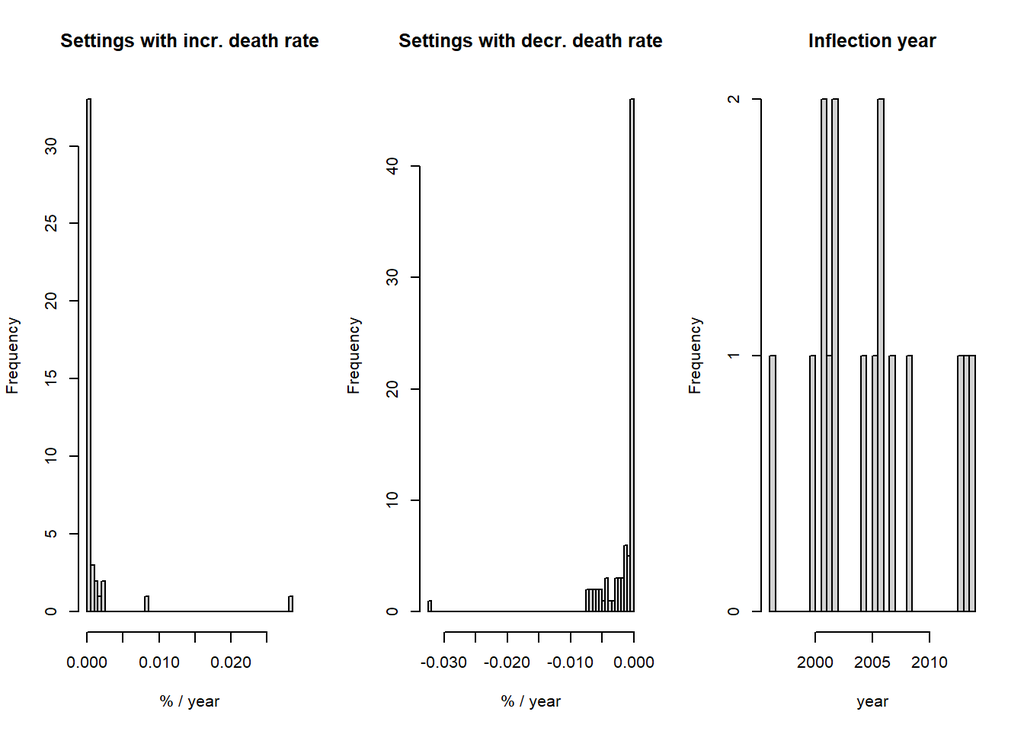

```r
par(mfrow=c(1,3))
hist(MCMCcoefs_DF$b1_median[MCMCcoefs_DF$b1_median>0],breaks=50,main='Settings with incr. death rate',
     xlab='% / year')
hist(MCMCcoefs_DF$b2_median[MCMCcoefs_DF$b2_median<0],breaks=50,main='Settings with decr. death rate',
     xlab='% / year')
hist(MCMCcoefs_DF$t_inflec_median,breaks=50,main='Inflection year',
     xlab='year')
```

[change from % to cases/10 000]

```r
#
#out.width=c('500px','300px','500px')
#,out.width=c('100%','100%','100%')
#R, fig.width=10, fig.height=7

MCMCcoefs_DF$b0_median= as.numeric(MCMCcoefs_DF$b0_median)
MCMCcoefs_DF$b1_median= as.numeric(MCMCcoefs_DF$b1_median)
MCMCcoefs_DF$b2_median= as.numeric(MCMCcoefs_DF$b2_median)
MCMCcoefs_DF$t_inflec_median= as.numeric(MCMCcoefs_DF$t_inflec_median)
str(MCMCcoefs_DF)
```

```
## 'data.frame':    126 obs. of  7 variables:
##  $ location       : Factor w/ 21 levels "Andean Latin America",..: 1 1 1 1 1 1 2 2 2 2 ...
##  $ cause          : Factor w/ 2 levels "HIV/AIDS","Tuberculosis": 1 1 1 2 2 2 1 1 1 2 ...
##  $ measure        : Factor w/ 3 levels "Deaths","Incidence",..: 1 2 3 1 2 3 1 2 3 1 ...
##  $ b0_median      : num  0.005725 0.000013 0.00029 0.076575 0.000394 ...
##  $ b1_median      : num  1.12e-03 4.84e-07 5.62e-05 0.00 0.00 ...
##  $ b2_median      : num  0.00 0.00 0.00 -2.46e-03 -1.13e-05 ...
##  $ t_inflec_median: num  NA NA NA NA NA NA NA NA NA NA ...
```

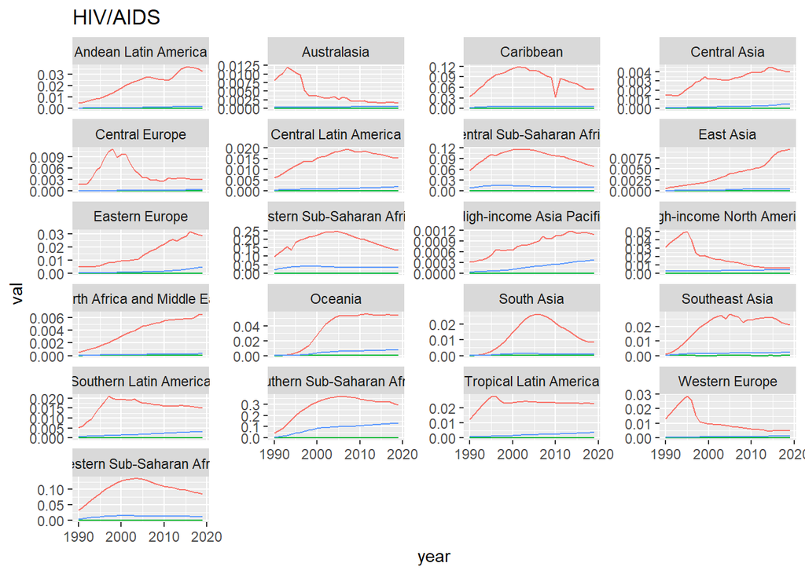

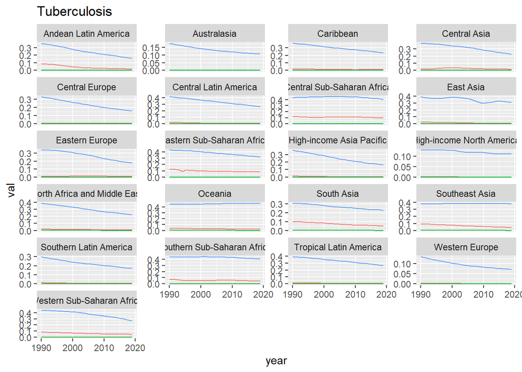

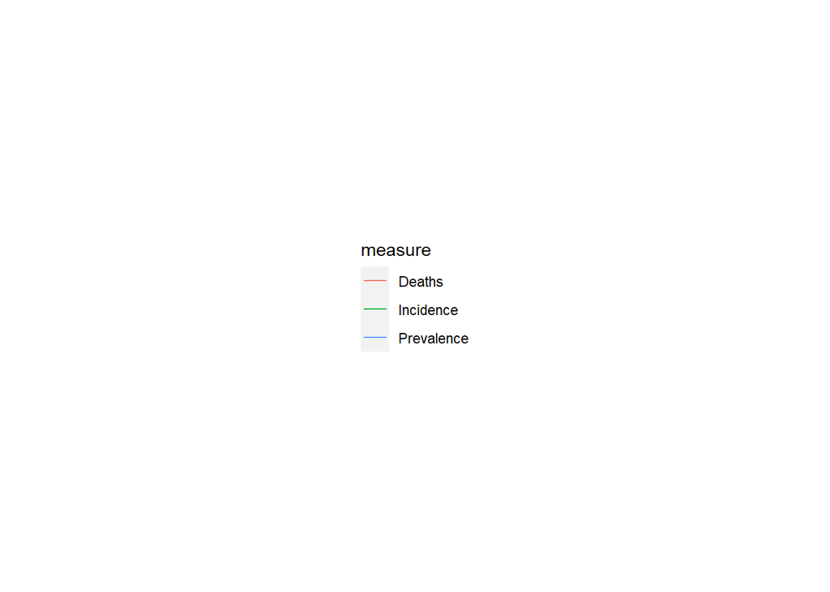

```r
ggplot(data=allTime_HT_asi[ allTime_HT_asi$cause=='HIV/AIDS',  ],
         mapping=aes(x=year,y=val,group=measure,color=measure))+
  geom_line()+
  ggtitle('HIV/AIDS')+
  guides(color="none")+
  facet_wrap(vars(location),ncol=4,scales='free_y')  #look at both fixed and free y

leg= ggpubr::get_legend(ggplot(data=allTime_HT_asi[ allTime_HT_asi$cause=='HIV/AIDS',  ],
                          mapping=aes(x=year,y=val,group=measure,color=measure))+
                          geom_line())

ggplot(data=allTime_HT_asi[ allTime_HT_asi$cause=='Tuberculosis',  ],
         mapping=aes(x=year,y=val,group=measure,color=measure))+
  geom_line()+
  ggtitle('Tuberculosis')+
  guides(color="none")+
  facet_wrap(vars(location),ncol=4,scales='free_y')  # look at both fixed and free y


leg= ggpubr::get_legend(ggplot(data=allTime_HT_asi[ allTime_HT_asi$cause=='HIV/AIDS',  ],
                          mapping=aes(x=year,y=val,group=measure,color=measure))+
                          geom_line() )
as_ggplot(leg)
```

Observations:

Tuberculosis: *the dynamics are quite different from HIV/AIDS* prevalence is higher than death rate in all regions *prevalence is generally declining or stable* death rate is generally declining from first recording on *there appears to be pos. correlation between prevalence and death rate, but with exceptions (e.g. countries with high prevalence and very low deaths) -> follow up on

| How meaningful are prevalence (and incidence) rates? Possible scenarios: |
| --- |
| *prevalence is tested in random sample; death rates should also be from |
| random samples or all deaths recorded |
| *all serious cases of the disease (the ones that may lead to death) are recorded |
| ->probably true for countries with decent healthcare system |
| *for each death it is determined if it was due to the cause of interest -> |
| depends on environment (e.g. autopsies at unknown cause of death?) and disease |
| manifestation (obvious signs of the disease?) |

## Summary of dynamics

Summarize the dynamics via coefficients b0 (level around 1990), b1 (increase rate), b2 (decline rate) and t0 (inflection point) [So far, I only plot entries with declining death rate, but it may be better to plot all and indicate value as missing if not confidently different from 0]

```r
MCMCcoefs_DF$loc_cause= paste(MCMCcoefs_DF$location,MCMCcoefs_DF$cause,sep=', ')
str(MCMCcoefs_DF)
```

```
## 'data.frame':    126 obs. of  8 variables:
##  $ location       : Factor w/ 21 levels "Andean Latin America",..: 1 1 1 1 1 1 2 2 2 2 ...
##  $ cause          : Factor w/ 2 levels "HIV/AIDS","Tuberculosis": 1 1 1 2 2 2 1 1 1 2 ...
##  $ measure        : Factor w/ 3 levels "Deaths","Incidence",..: 1 2 3 1 2 3 1 2 3 1 ...
##  $ b0_median      : num  0.005725 0.000013 0.00029 0.076575 0.000394 ...
##  $ b1_median      : num  1.12e-03 4.84e-07 5.62e-05 0.00 0.00 ...
##  $ b2_median      : num  0.00 0.00 0.00 -2.46e-03 -1.13e-05 ...
##  $ t_inflec_median: num  NA NA NA NA NA NA NA NA NA NA ...
##  $ loc_cause      : chr  "Andean Latin America, HIV/AIDS" "Andean Latin America, HIV/AIDS" "Andean Latin America, HIV/AIDS" "Andean Latin America, Tuberculosis" ...
```

```r
#pivot:
MCMCcoefs_wide= pivot_wider(data=MCMCcoefs_DF,id_cols=c('loc_cause','location','cause'),
            names_from = c('measure'),
            values_from=c('b0_median','b1_median','b2_median','t_inflec_median'))

#manually sorted:
MCMCcoefs_DF_NA= MCMCcoefs_wide[is.na(MCMCcoefs_wide$t_inflec_median_Deaths),] #no inflection point
MCMCcoefs_DF_noNA= MCMCcoefs_wide[!is.na(MCMCcoefs_wide$t_inflec_median_Deaths),] #with inflection point

#out of the data that do not have inflection year, get the ones that have decline
MCMCcoefs_DF_NA_decl= MCMCcoefs_DF_NA[MCMCcoefs_DF_NA$b2_median_Deaths!=0,]
MCMCcoefs_DF_NA_nodecl= MCMCcoefs_DF_NA[MCMCcoefs_DF_NA$b2_median_Deaths==0,]

#sort data with declining death rate (but no inflection) by decline of death rate
ord1= order(MCMCcoefs_DF_NA_decl$b2_median_Deaths)
#sort data with inflection by inflection year
ord2= order(MCMCcoefs_DF_noNA$t_inflec_median_Deaths) + max(c(0,ord1)) #start after ord1
#sort data without declining death rate by increase in death rate
ord3= order(MCMCcoefs_DF_NA_nodecl$b1_median_Deaths) + max(c(0,ord2)) #start after ord2

#order factor levels of 'loc_cause'
MCMCcoefs_patchw= rbind.data.frame(MCMCcoefs_DF_NA_decl,MCMCcoefs_DF_noNA,MCMCcoefs_DF_NA_nodecl)
ord= c(ord1,ord2,ord3)
MCMCcoefs_patchw$loc_cause= factor(MCMCcoefs_patchw$loc_cause,ordered=TRUE,
           levels= MCMCcoefs_patchw$loc_cause[ord])

DrD_melt= melt(MCMCcoefs_patchw,id.vars= c('loc_cause','location','cause'),
    measure.vars=
      c('b0_median_Deaths','b1_median_Deaths','b2_median_Deaths','t_inflec_median_Deaths',
        'b0_median_Prevalence','b1_median_Prevalence',
        'b2_median_Prevalence'  ))
 #drop Incidence (very low):'b0_median_Incidence', 'b1_median_Incidence','b2_median_Incidence','t_inflec_median_Incidence'
 #drop inflection of prevalence (very few observed): ,'t_inflec_median_Prevalence'
str(DrD_melt)
```

```
## 'data.frame':    294 obs. of  5 variables:
##  $ loc_cause: Ord.factor w/ 42 levels "Andean Latin America, Tuberculosis"<..: 1 16 23 18 8 20 12 4 9 7 ...
##  $ location : Factor w/ 21 levels "Andean Latin America",..: 1 2 2 3 4 5 6 7 8 10 ...
##  $ cause    : Factor w/ 2 levels "HIV/AIDS","Tuberculosis": 2 1 2 2 2 2 2 2 2 2 ...
##  $ variable : Factor w/ 7 levels "b0_median_Deaths",..: 1 1 1 1 1 1 1 1 1 1 ...
##  $ value    : num  0.076575 0.00822 0.000799 0.016243 0.028248 ...
```

```r
DrD_melt$coefType= rep('rate',dim(DrD_melt)[1])
DrD_melt$coefType[DrD_melt$variable %in% c('b0_median_Deaths',
                  'b0_median_Prevalence','b0_median_Incidence')]= 'basel.'
DrD_melt$coefType[DrD_melt$variable %in% c('t_inflec_median_Deaths',
                  't_inflec_median_Prevalence','t_inflec_median_Incidence')]= 'year'
head(DrD_melt)
```

|  | loc_cause | location | cause | variable | value | coefType |
| --- | --- | --- | --- | --- | --- | --- |
| 1 | Andean Latin America, Tuberculosis | Andean Latin America | Tuberculosis | b0_median_Deaths | 0.0765746093 | basel. |
| 2 | Australasia, HIV/AIDS | Australasia | HIV/AIDS | b0_median_Deaths | 0.0082204252 | basel. |
| 3 | Australasia, Tuberculosis | Australasia | Tuberculosis | b0_median_Deaths | 0.0007991389 | basel. |
| 4 | Caribbean, Tuberculosis | Caribbean | Tuberculosis | b0_median_Deaths | 0.0162433765 | basel. |
| 5 | Central Asia, Tuberculosis | Central Asia | Tuberculosis | b0_median_Deaths | 0.0282482063 | basel. |
| 6 | Central Europe, Tuberculosis | Central Europe | Tuberculosis | b0_median_Deaths | 0.0063972962 | basel. |

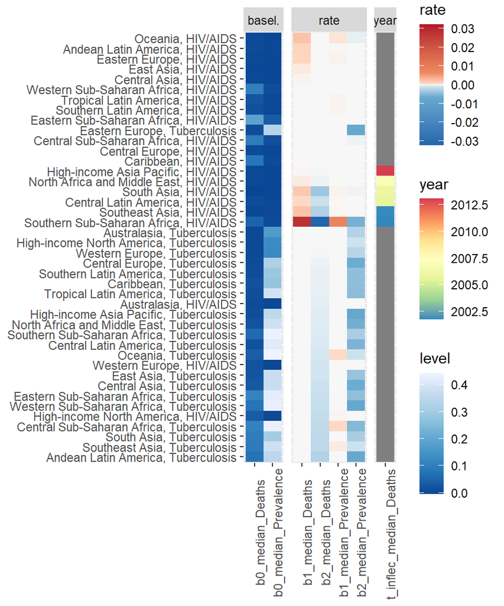

```r
ggplot()+
  geom_tile(data=DrD_melt[DrD_melt$coefType=='rate',],aes(x=variable,y=loc_cause,fill=value))+
  scale_fill_distiller(type = "seq", palette = "RdBu",
  limits=c(-max(abs(DrD_melt$value[DrD_melt$coefType=='rate'])),max(abs(DrD_melt$value[DrD_melt$coefType=='rate']))), values=c(0,.4,.49,.5,.51,.6,1), guide = guide_colorbar(title.position = "top"),name='rate') +
  ggnewscale::new_scale_fill() +
  geom_tile(data=DrD_melt[DrD_melt$coefType=='basel.',],aes(x=variable,y=loc_cause,fill=value))+
  scale_fill_distiller(type = "seq", palette = "Blues", guide=guide_colorbar(title.position = "top"),name='level') +
  ggnewscale::new_scale_fill() +
  geom_tile(data=DrD_melt[DrD_melt$coefType=='year',],aes(x=variable,y=loc_cause,fill=value))+
  scale_fill_distiller(type = "div", palette = "Spectral", guide = guide_colorbar(title.position = "top"),name='year') +
  theme(axis.text.x=element_text(angle=90),axis.title.y=element_blank(),axis.title.x=element_blank())+
  facet_grid(.~coefType, scales = "free_x", space = "free_x")
```

The strategy for condensing the 30-year behavior into 4 coefficients seems promising. Let`s apply it to more causes.

# 10 additional causes

Load data

```r
allTime_10caus_1= read.csv('./20230911_DeathPrevInci_10caus_21reg_MF_5year/IHME-GBD_2019_DATA-d86a6f40-1.csv',stringsAsFactors = TRUE)
allTime_10caus_2= read.csv('./20230911_DeathPrevInci_10caus_21reg_MF_5year/IHME-GBD_2019_DATA-d86a6f40-2.csv',stringsAsFactors = TRUE)
allTime_10caus_3= read.csv('./20230911_DeathPrevInci_10caus_21reg_MF_5year/IHME-GBD_2019_DATA-d86a6f40-3.csv',stringsAsFactors = TRUE)
allTime_10caus= rbind.data.frame(allTime_10caus_1,allTime_10caus_2,allTime_10caus_3)
allTime_10caus= allTime_10caus[allTime_10caus$metric=='Percent',]
unique(allTime_10caus$metric)
```

```
## [1] Percent
## Levels: Percent Rate
```

```r
str(allTime_10caus)
```

```
## 'data.frame':    652680 obs. of  10 variables:
##  $ measure : Factor w/ 3 levels "Deaths","Prevalence",..: 1 1 1 1 1 1 1 1 1 1 ...
##  $ location: Factor w/ 21 levels "Andean Latin America",..: 4 4 4 4 4 4 4 4 4 4 ...
##  $ sex     : Factor w/ 2 levels "Female","Male": 2 1 2 1 2 1 2 1 2 1 ...
##  $ age     : Factor w/ 18 levels "1-4 years","10-14 years",..: 1 1 9 9 2 2 3 3 4 4 ...
##  $ cause   : Factor w/ 10 levels "Diarrheal diseases",..: 9 9 9 9 9 9 9 9 9 9 ...
##  $ metric  : Factor w/ 2 levels "Percent","Rate": 1 1 1 1 1 1 1 1 1 1 ...
##  $ year    : int  1991 1991 1991 1991 1991 1991 1991 1991 1991 1991 ...
##  $ val     : num  0.000919 0.001201 0.002354 0.004431 0.003152 ...
##  $ upper   : num  0.00127 0.00164 0.00294 0.00552 0.0038 ...
##  $ lower   : num  0.000541 0.000797 0.001906 0.003651 0.00262 ...
```

```r
dim(allTime_10caus)
```

```
## [1] 652680     10
```

Clean

```r
unique(allTime_10caus$age) #this indicates entry "80-84" instead of "80-84 years" and two other such cases
```

```
##  [1] 1-4 years   5-9 years   10-14 years 15-19 years 20-24 years 25-29 years
##  [7] 30-34 years 40-44 years 45-49 years 50-54 years 55-59 years 60-64 years
## [13] 65-69 years 70-74 years 75-79 years 80-84       85-89       90-94
## 18 Levels: 1-4 years 10-14 years 15-19 years 20-24 years ... 90-94
```

```r
levels(allTime_10caus$age)[levels(allTime_10caus$age)=='80-84']= '80-84 years'
levels(allTime_10caus$age)[levels(allTime_10caus$age)=='85-89']= '85-89 years'
levels(allTime_10caus$age)[levels(allTime_10caus$age)=='90-94']= '90-94 years'
levels(allTime_10caus$age)
```

```
##  [1] "1-4 years"   "10-14 years" "15-19 years" "20-24 years" "25-29 years"
##  [6] "30-34 years" "40-44 years" "45-49 years" "5-9 years"   "50-54 years"
## [11] "55-59 years" "60-64 years" "65-69 years" "70-74 years" "75-79 years"
## [16] "80-84 years" "85-89 years" "90-94 years"
```

```r
# cleaning: remove causes for which not all three measures are listed
unique(allTime_10caus$measure[allTime_10caus$cause=='Guinea worm disease'])
```

```
## [1] Prevalence Incidence
## Levels: Deaths Prevalence Incidence
```

```r
 #apparently causes that does not have any death associated does not have Deaths metric
incomplete_causes= c()
for (ca in unique(allTime_10caus$cause)){
  len= length(unique(allTime_10caus$measure[allTime_10caus$cause==ca]))
  if(len != 3){
    incomplete_causes= c(incomplete_causes,ca)
  }
}
allTime_10caus= allTime_10caus[! allTime_10caus$cause %in% incomplete_causes,]
```

## Age- & sex- independent analysis

Simplify data: Average percentages over all age groups for location-cause-year combination

```r
allTime_10caus_asi= data.frame( allTime_10caus %>%   #asi= age-, sex- independent
  group_by(measure,location,cause,year) %>%
  summarize(val= mean(val),.groups='drop') )
head(allTime_10caus_asi)
```

|  | measure | location | cause | year | val |
| --- | --- | --- | --- | --- | --- |
| 1 | Deaths | Andean Latin America | Diarrheal diseases | 1990 | 0.02405603 |
| 2 | Deaths | Andean Latin America | Diarrheal diseases | 1991 | 0.02565334 |
| 3 | Deaths | Andean Latin America | Diarrheal diseases | 1992 | 0.02423331 |
| 4 | Deaths | Andean Latin America | Diarrheal diseases | 1993 | 0.02336296 |
| 5 | Deaths | Andean Latin America | Diarrheal diseases | 1994 | 0.02210943 |
| 6 | Deaths | Andean Latin America | Diarrheal diseases | 1995 | 0.02136141 |

```r
dim(allTime_10caus_asi)
```

```
## [1] 17010     5
```

Visualize data

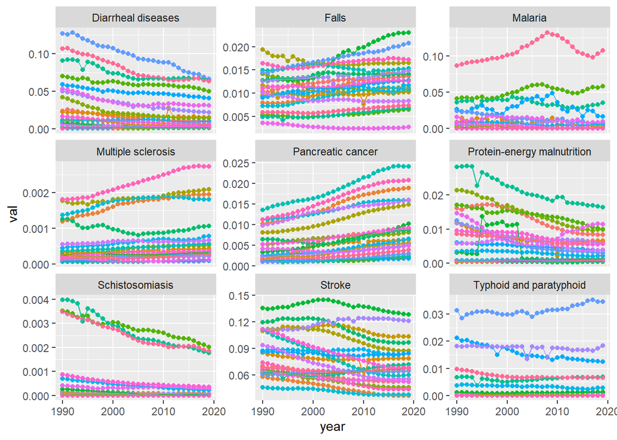

```r
ggplot(data=allTime_10caus_asi[allTime_10caus_asi$measure=='Deaths',],mapping=aes(x=year,y=val,group=location,color=location))+
  geom_point()+
  geom_line()+
  facet_wrap(~cause,scales='free_y')+
  guides(color='none')
```

Two-line model

```r
groupedDF= allTime_10caus_asi %>%
      group_by(location,cause,measure) %>%
      summarize(n(),.groups='drop')
dim(groupedDF) #609 combinations
```

```
## [1] 567   4
```

```r
head(allTime_10caus_asi)
```

|  | measure | location | cause | year | val |
| --- | --- | --- | --- | --- | --- |
| 1 | Deaths | Andean Latin America | Diarrheal diseases | 1990 | 0.02405603 |
| 2 | Deaths | Andean Latin America | Diarrheal diseases | 1991 | 0.02565334 |
| 3 | Deaths | Andean Latin America | Diarrheal diseases | 1992 | 0.02423331 |
| 4 | Deaths | Andean Latin America | Diarrheal diseases | 1993 | 0.02336296 |
| 5 | Deaths | Andean Latin America | Diarrheal diseases | 1994 | 0.02210943 |
| 6 | Deaths | Andean Latin America | Diarrheal diseases | 1995 | 0.02136141 |

```r
#groupedDF= groupedDF[groupedDF$location == 'Andean Latin America',]  ###,'Eastern Europe','South Asia' only temporary

if(! file.exists('./20230914_MCMCcoefs_10caus.csv')){ #execute only if not yet done
  MCMCcoefs_DF_10caus= data.frame( matrix(NA,nrow=dim(groupedDF)[1],ncol=7))
  colnames(MCMCcoefs_DF_10caus)= c('location','cause','measure',
                            'b0_median','b1_median','b2_median','t_inflec_median')
  MCMCcoefs_DF_10caus$location <- factor(MCMCcoefs_DF_10caus$location, levels = levels(groupedDF$location))
  MCMCcoefs_DF_10caus$cause <- factor(MCMCcoefs_DF_10caus$cause, levels = levels(groupedDF$cause))
  MCMCcoefs_DF_10caus$measure <- factor(MCMCcoefs_DF_10caus$measure, levels = levels(groupedDF$measure))

  for(i in 1:dim(groupedDF)[1]){
    print(paste(i,'of',dim(groupedDF)[1]))
    currDF= allTime_10caus_asi[allTime_10caus_asi$location==groupedDF$location[i] &
                          allTime_10caus_asi$cause==groupedDF$cause[i] &
                          allTime_10caus_asi$measure==groupedDF$measure[i]  ,]
    mcmcDF_orig= twoLine_fit(t= currDF$year, y=currDF$val)

    #There are two coefficients (b1, b2) that each can either be present of absent as indicated by indicator      factors
    mcmcDF_orig$iF1= factor(mcmcDF_orig$iF1, levels=c(0,1)) #to make sure both levels are listed even if only one observed
    mcmcDF_orig$iF2= factor(mcmcDF_orig$iF2, levels=c(0,1))
    tab2Way= data.table(table(cbind.data.frame(iF1=mcmcDF_orig$iF1, iF2=mcmcDF_orig$iF2)))
     #find the most frequent combination of indicator factors -> the best model
    iF1_best= tab2Way$iF1[tab2Way$N==max(tab2Way$N)]
    iF2_best= tab2Way$iF2[tab2Way$N==max(tab2Way$N)]

    #Reduce to MCMC output of the best model
    mcmcDF= mcmcDF_orig[mcmcDF_orig$iF1==iF1_best & mcmcDF_orig$iF2==iF2_best,]
    if(iF1_best==0 | iF2_best==0){
      mcmcDF$t0= NA
    }

    #Analysis could be extended by cases cross-informing each other (e.g. countries from same
     #region)

    MCMCcoefs_DF_10caus$location[i]= groupedDF$location[i]
    MCMCcoefs_DF_10caus$cause[i]= groupedDF$cause[i]
    MCMCcoefs_DF_10caus$measure[i]= groupedDF$measure[i]
    MCMCcoefs_DF_10caus$b0_median[i]= median(mcmcDF$b0)
    MCMCcoefs_DF_10caus$b1_median[i]= median(mcmcDF$b1)
    MCMCcoefs_DF_10caus$b2_median[i]= median(mcmcDF$b2)
    MCMCcoefs_DF_10caus$t_inflec_median[i]= median(mcmcDF$t0)  #may be NA
  }

  # write output so you do not need to run this code every time
  write.csv(MCMCcoefs_DF_10caus, './20230914_MCMCcoefs_10caus.csv', row.names = FALSE)
} else {
  MCMCcoefs_DF_10caus= read.csv('./20230914_MCMCcoefs_10caus.csv', stringsAsFactors=TRUE)
}
str(MCMCcoefs_DF_10caus)
```

```
## 'data.frame':    567 obs. of  7 variables:
##  $ location       : Factor w/ 21 levels "Andean Latin America",..: 1 1 1 1 1 1 1 1 1 1 ...
##  $ cause          : Factor w/ 9 levels "Diarrheal diseases",..: 1 1 1 2 2 2 3 3 3 4 ...
##  $ measure        : Factor w/ 3 levels "Deaths","Incidence",..: 1 3 2 1 3 2 1 3 2 1 ...
##  $ b0_median      : num  0.0225 0.0162 0.1521 0.0103 0.0501 ...
##  $ b1_median      : num  0 0.000347 0.002984 0.000218 0.001114 ...
##  $ b2_median      : num  -0.000538 -0.000131 -0.001337 -0.000148 -0.000707 ...
##  $ t_inflec_median: num  NA 2000 2002 1999 2003 ...
```

```r
dim(MCMCcoefs_DF_10caus)
```

```
## [1] 567   7
```

```r
MCMCcoefs_DF_10caus$loc_cause= paste(MCMCcoefs_DF_10caus$location,MCMCcoefs_DF_10caus$cause,sep=', ')
str(MCMCcoefs_DF_10caus)
```

```
## 'data.frame':    567 obs. of  8 variables:
##  $ location       : Factor w/ 21 levels "Andean Latin America",..: 1 1 1 1 1 1 1 1 1 1 ...
##  $ cause          : Factor w/ 9 levels "Diarrheal diseases",..: 1 1 1 2 2 2 3 3 3 4 ...
##  $ measure        : Factor w/ 3 levels "Deaths","Incidence",..: 1 3 2 1 3 2 1 3 2 1 ...
##  $ b0_median      : num  0.0225 0.0162 0.1521 0.0103 0.0501 ...
##  $ b1_median      : num  0 0.000347 0.002984 0.000218 0.001114 ...
##  $ b2_median      : num  -0.000538 -0.000131 -0.001337 -0.000148 -0.000707 ...
##  $ t_inflec_median: num  NA 2000 2002 1999 2003 ...
##  $ loc_cause      : chr  "Andean Latin America, Diarrheal diseases" "Andean Latin America, Diarrheal diseases" "Andean Latin America, Diarrheal diseases" "Andean Latin America, Falls" ...
```

```r
str(MCMCcoefs_DF)
```

```
## 'data.frame':    126 obs. of  8 variables:
##  $ location       : Factor w/ 21 levels "Andean Latin America",..: 1 1 1 1 1 1 2 2 2 2 ...
##  $ cause          : Factor w/ 2 levels "HIV/AIDS","Tuberculosis": 1 1 1 2 2 2 1 1 1 2 ...
##  $ measure        : Factor w/ 3 levels "Deaths","Incidence",..: 1 2 3 1 2 3 1 2 3 1 ...
##  $ b0_median      : num  0.005725 0.000013 0.00029 0.076575 0.000394 ...
##  $ b1_median      : num  1.12e-03 4.84e-07 5.62e-05 0.00 0.00 ...
##  $ b2_median      : num  0.00 0.00 0.00 -2.46e-03 -1.13e-05 ...
##  $ t_inflec_median: num  NA NA NA NA NA NA NA NA NA NA ...
##  $ loc_cause      : chr  "Andean Latin America, HIV/AIDS" "Andean Latin America, HIV/AIDS" "Andean Latin America, HIV/AIDS" "Andean Latin America, Tuberculosis" ...
```

```r
#combine with data from HT
MCMCcoefs_DF_comb= rbind.data.frame(MCMCcoefs_DF,MCMCcoefs_DF_10caus)

#pivot:
MCMCcoefs_wide= pivot_wider(data=MCMCcoefs_DF_comb,id_cols=c('loc_cause','location','cause'),
            names_from = c('measure'),
            values_from=c('b0_median','b1_median','b2_median','t_inflec_median'))

#manually sorted:
MCMCcoefs_DF_NA= MCMCcoefs_wide[is.na(MCMCcoefs_wide$t_inflec_median_Deaths),] #no inflection point
MCMCcoefs_DF_noNA= MCMCcoefs_wide[!is.na(MCMCcoefs_wide$t_inflec_median_Deaths),] #with inflection point

#out of the data that do not have inflection year, get the ones that have decline
MCMCcoefs_DF_NA_decl= MCMCcoefs_DF_NA[MCMCcoefs_DF_NA$b2_median_Deaths!=0,]
MCMCcoefs_DF_NA_nodecl= MCMCcoefs_DF_NA[MCMCcoefs_DF_NA$b2_median_Deaths==0,]

#sort data with declining death rate (but no inflection) by decline of death rate
ord1= order(MCMCcoefs_DF_NA_decl$b2_median_Deaths)
#sort data with inflection by inflection year
ord2= order(MCMCcoefs_DF_noNA$t_inflec_median_Deaths) + max(c(0,ord1)) #start after ord1
#sort data without declining death rate by increase in death rate
ord3= order(MCMCcoefs_DF_NA_nodecl$b1_median_Deaths) + max(c(0,ord2)) #start after ord2

#order factor levels of 'loc_cause'
MCMCcoefs_patchw= rbind.data.frame(MCMCcoefs_DF_NA_decl,MCMCcoefs_DF_noNA,MCMCcoefs_DF_NA_nodecl)
ord= c(ord1,ord2,ord3)
MCMCcoefs_patchw$loc_cause= factor(MCMCcoefs_patchw$loc_cause,ordered=TRUE,
           levels= MCMCcoefs_patchw$loc_cause[ord])

DrD_melt= melt(MCMCcoefs_patchw,id.vars= c('loc_cause','location','cause'),
    measure.vars=
      c('b0_median_Deaths','b1_median_Deaths','b2_median_Deaths','t_inflec_median_Deaths',
        'b0_median_Prevalence','b1_median_Prevalence',
        'b2_median_Prevalence'  ))
 #drop Incidence (very low):'b0_median_Incidence', 'b1_median_Incidence','b2_median_Incidence','t_inflec_median_Incidence'
 #drop inflection of prevalence (very few observed): ,'t_inflec_median_Prevalence'
str(DrD_melt)
```

```
## 'data.frame':    1617 obs. of  5 variables:
##  $ loc_cause: Ord.factor w/ 231 levels "Andean Latin America, Tuberculosis"<..: 1 50 87 55 16 61 34 9 24 14 ...
##  $ location : Factor w/ 21 levels "Andean Latin America",..: 1 2 2 3 4 5 6 7 8 10 ...
##  $ cause    : Factor w/ 11 levels "HIV/AIDS","Tuberculosis",..: 2 1 2 2 2 2 2 2 2 2 ...
##  $ variable : Factor w/ 7 levels "b0_median_Deaths",..: 1 1 1 1 1 1 1 1 1 1 ...
##  $ value    : num  0.076575 0.00822 0.000799 0.016243 0.028248 ...
```

```r
DrD_melt$coefType= rep('rate',dim(DrD_melt)[1])
DrD_melt$coefType[DrD_melt$variable %in% c('b0_median_Deaths',
                  'b0_median_Prevalence','b0_median_Incidence')]= 'basel.'
DrD_melt$coefType[DrD_melt$variable %in% c('t_inflec_median_Deaths',
                  't_inflec_median_Prevalence','t_inflec_median_Incidence')]= 'year'
head(DrD_melt)
```

|  | loc_cause | location | cause | variable | value | coefType |
| --- | --- | --- | --- | --- | --- | --- |
| 1 | Andean Latin America, Tuberculosis | Andean Latin America | Tuberculosis | b0_median_Deaths | 0.0765746093 | basel. |
| 2 | Australasia, HIV/AIDS | Australasia | HIV/AIDS | b0_median_Deaths | 0.0082204252 | basel. |
| 3 | Australasia, Tuberculosis | Australasia | Tuberculosis | b0_median_Deaths | 0.0007991389 | basel. |
| 4 | Caribbean, Tuberculosis | Caribbean | Tuberculosis | b0_median_Deaths | 0.0162433765 | basel. |
| 5 | Central Asia, Tuberculosis | Central Asia | Tuberculosis | b0_median_Deaths | 0.0282482063 | basel. |
| 6 | Central Europe, Tuberculosis | Central Europe | Tuberculosis | b0_median_Deaths | 0.0063972962 | basel. |

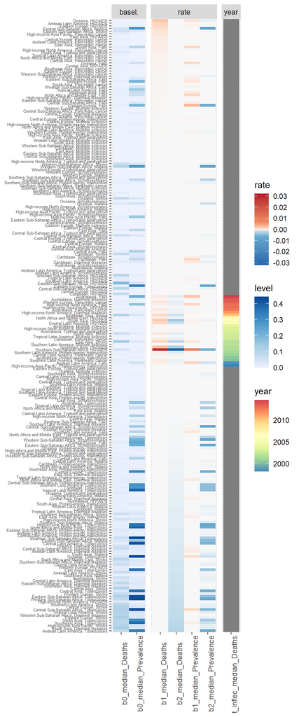

```r
ggplot()+
  geom_tile(data=DrD_melt[DrD_melt$coefType=='rate',],aes(x=variable,y=loc_cause,fill=value))+
  scale_fill_distiller(type = "seq", palette = "RdBu",
  limits=c(-max(abs(DrD_melt$value[DrD_melt$coefType=='rate'])),max(abs(DrD_melt$value[DrD_melt$coefType=='rate']))), values=c(0,.4,.49,.5,.51,.6,1), guide = guide_colorbar(title.position = "top"),name='rate') +
  ggnewscale::new_scale_fill() +
  geom_tile(data=DrD_melt[DrD_melt$coefType=='basel.',],aes(x=variable,y=loc_cause,fill=value))+
  scale_fill_distiller(type = "seq", palette = "Blues", values=seq(1,0,-.1), guide=guide_colorbar(title.position = "top"),name='level') +
  ggnewscale::new_scale_fill() +
  geom_tile(data=DrD_melt[DrD_melt$coefType=='year',],aes(x=variable,y=loc_cause,fill=value))+
  scale_fill_distiller(type = "div", palette = "Spectral", guide = guide_colorbar(title.position = "top"),name='year') +
  theme(axis.title.x=element_blank(),axis.text.x=element_text(angle=90),
        axis.title.y=element_blank(),axis.text.y=element_text(size=5),)+
  facet_grid(.~coefType, scales = "free_x", space = "free_x")
```

[For entries with only decline rate, but not increase rate it would be better to set inflection year to NA]

# Identification of factors associated with decreasing deaths

I will next use the technique of summarizing time courses into four parameters to learn the factors associated with declining deaths (b2 < 0). I will use a random forest approach. Process the data individually for each age group and sex to have features for classification. Indicate the various categories by which locations can be grouped (e.g. continent, high/low income, …)

```r
# Start with only HIV and Tuberculosis
allTime_HT= allTime_HTZ[allTime_HTZ$cause %in% c('HIV/AIDS','Tuberculosis'),]

#limit to death rate (not prevalence or incidence)
allTime_HT_D= allTime_HT[allTime_HT$measure=='Deaths',]
head(allTime_HT_D)
```

|  | measure | location | sex | age | cause | metric | year | val | upper | lower |
| --- | --- | --- | --- | --- | --- | --- | --- | --- | --- | --- |
| 103 | Deaths | Southern Sub-Saharan Africa | Male | 1-4 years | Tuberculosis | Percent | 1991 | 0.05828452 | 0.07584042 | 0.04230566 |
| 104 | Deaths | Southern Sub-Saharan Africa | Female | 1-4 years | Tuberculosis | Percent | 1991 | 0.05118780 | 0.07327022 | 0.03400883 |
| 107 | Deaths | Southern Sub-Saharan Africa | Male | 5-9 years | Tuberculosis | Percent | 1991 | 0.06739403 | 0.08315998 | 0.05393467 |
| 108 | Deaths | Southern Sub-Saharan Africa | Female | 5-9 years | Tuberculosis | Percent | 1991 | 0.07159152 | 0.09918324 | 0.05226830 |
| 111 | Deaths | Southern Sub-Saharan Africa | Male | 10-14 years | Tuberculosis | Percent | 1991 | 0.05712411 | 0.07021589 | 0.04669703 |
| 112 | Deaths | Southern Sub-Saharan Africa | Female | 10-14 years | Tuberculosis | Percent | 1991 | 0.07660581 | 0.10223418 | 0.06012578 |

Visualize data

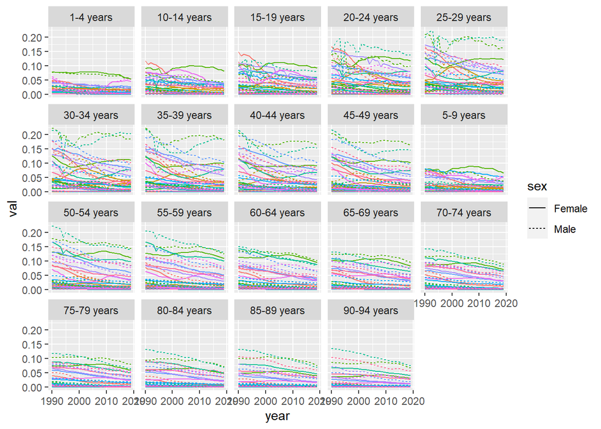

```r
#Tuberculosis
ggplot(data=allTime_HT_D[allTime_HT_D$cause=='Tuberculosis',],mapping=aes(x=year,y=val,group=interaction(location,sex),color=location,lty=sex))+
  #geom_point()+
  geom_line()+
  facet_wrap(~age)+ #,scales='free_y'
  guides(color='none')
```

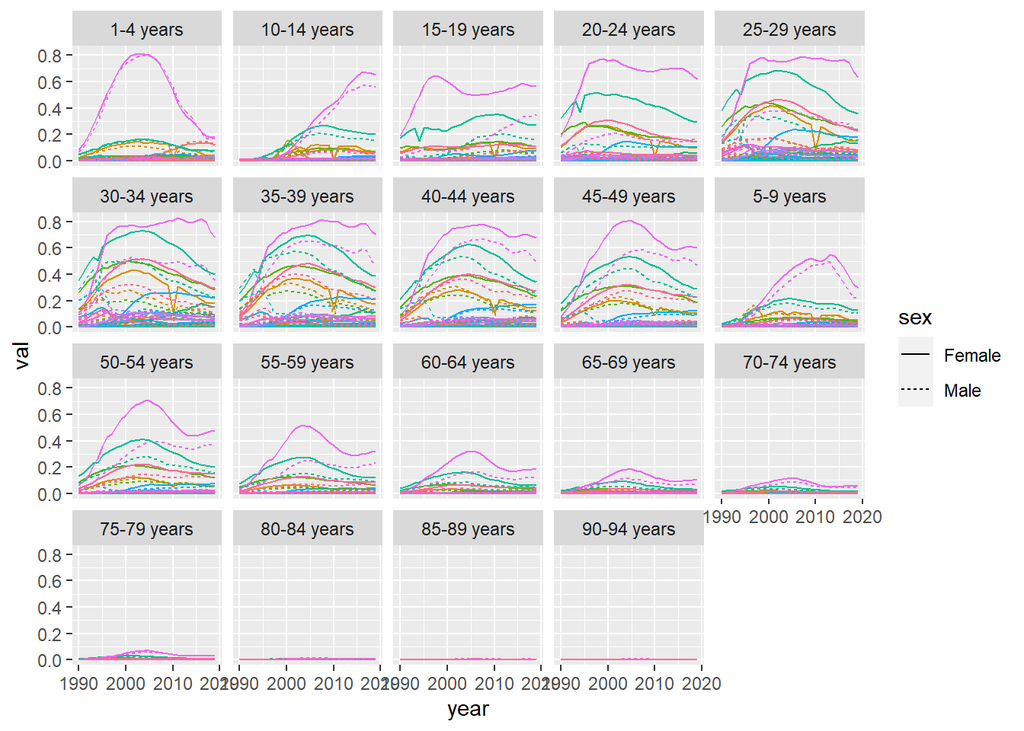

```r
ggplot(data=allTime_HT_D[allTime_HT_D$cause=='HIV/AIDS',],mapping=aes(x=year,y=val,group=interaction(location,sex),color=location,lty=sex))+
  #geom_point()+
  geom_line()+
  facet_wrap(~age)+ #,scales='free_y'
  guides(color='none')
```

Visual impression: Tuberculosis: It seems the same locations have highest rates over all age groups; in most of the groups deaths decrease over time; men generally have higher rates; middle aged individuals have higher number of deaths than very young and very old people

HIV/AIDS: *frequently increase till ~2005, then decrease* similar ordering of countries over age groups *Highest rates in middle aged populations* Women generally have higher rates than men

!!! Careful with the analysis within age groups: I assume(!) the data give number of deaths per overall population of the location, not percentage within the age group -> you need to consider the demographics of the country [the same problem also applies to sex, but probably much less severely]

```r
groupedDF= allTime_HT_D %>%
      group_by(location,cause,measure,sex,age) %>%
      summarize(n(),.groups='drop')
dim(groupedDF) #1596 combinations
```

```
## [1] 1596    6
```

```r
#groupedDF= groupedDF[groupedDF$location == 'Andean Latin America',]  ###,'Eastern Europe','South Asia' only temporary

if(! file.exists('./20230915_MCMCcoefs_HTsex_age.csv')){ #execute only if not yet done
  MCMCcoefs_DF_HTsex_age= data.frame( matrix(NA,nrow=dim(groupedDF)[1],ncol=9))
  colnames(MCMCcoefs_DF_HTsex_age)= c('location','cause','measure','sex','age',
                            'b0_median','b1_median','b2_median','t_inflec_median')
  MCMCcoefs_DF_HTsex_age$location <- factor(MCMCcoefs_DF_HTsex_age$location, levels = levels(groupedDF$location))
  MCMCcoefs_DF_HTsex_age$cause <- factor(MCMCcoefs_DF_HTsex_age$cause, levels = levels(groupedDF$cause))
  MCMCcoefs_DF_HTsex_age$measure <- factor(MCMCcoefs_DF_HTsex_age$measure, levels = levels(groupedDF$measure))
  MCMCcoefs_DF_HTsex_age$sex <- factor(MCMCcoefs_DF_HTsex_age$sex, levels = levels(groupedDF$sex))
  MCMCcoefs_DF_HTsex_age$age <- factor(MCMCcoefs_DF_HTsex_age$age, levels = levels(groupedDF$age))

  for(i in 1:dim(groupedDF)[1]){
    print(paste(i,'of',dim(groupedDF)[1]))
    currDF= allTime_HT_D[allTime_HT_D$location==groupedDF$location[i] &
                          allTime_HT_D$cause==groupedDF$cause[i] &
                          allTime_HT_D$measure==groupedDF$measure[i] &
                          allTime_HT_D$sex==groupedDF$sex[i] &
                          allTime_HT_D$age==groupedDF$age[i],]
    mcmcDF_orig= twoLine_fit(t= currDF$year, y=currDF$val)

    #There are two coefficients (b1, b2) that each can either be present of absent as indicated by indicator      factors
    mcmcDF_orig$iF1= factor(mcmcDF_orig$iF1, levels=c(0,1)) #to make sure both levels are listed even if only one observed
    mcmcDF_orig$iF2= factor(mcmcDF_orig$iF2, levels=c(0,1))
    tab2Way= data.table(table(cbind.data.frame(iF1=mcmcDF_orig$iF1, iF2=mcmcDF_orig$iF2)))
     #find the most frequent combination of indicator factors -> the best model
    iF1_best= tab2Way$iF1[tab2Way$N==max(tab2Way$N)]
    iF2_best= tab2Way$iF2[tab2Way$N==max(tab2Way$N)]

    #Reduce to MCMC output of the best model
    mcmcDF= mcmcDF_orig[mcmcDF_orig$iF1==iF1_best & mcmcDF_orig$iF2==iF2_best,]
    if(iF1_best==0 | iF2_best==0){
      mcmcDF$t0= NA
    }

    #Analysis could be extended by cases cross-informing each other (e.g. countries from same
     #region)

    MCMCcoefs_DF_HTsex_age$location[i]= groupedDF$location[i]
    MCMCcoefs_DF_HTsex_age$cause[i]= groupedDF$cause[i]
    MCMCcoefs_DF_HTsex_age$measure[i]= groupedDF$measure[i]
    MCMCcoefs_DF_HTsex_age$sex[i]= groupedDF$sex[i]
    MCMCcoefs_DF_HTsex_age$age[i]= groupedDF$age[i]
    MCMCcoefs_DF_HTsex_age$b0_median[i]= median(mcmcDF$b0)
    MCMCcoefs_DF_HTsex_age$b1_median[i]= median(mcmcDF$b1)
    MCMCcoefs_DF_HTsex_age$b2_median[i]= median(mcmcDF$b2)
    MCMCcoefs_DF_HTsex_age$t_inflec_median[i]= median(mcmcDF$t0)  #may be NA
  }

  # write output so you do not need to run this code every time
  write.csv(MCMCcoefs_DF, './20230915_MCMCcoefs_HTsex_age.csv', row.names = FALSE)
} else {
  MCMCcoefs_DF_HTsex_age= read.csv('./20230915_MCMCcoefs_HTsex_age.csv', stringsAsFactors=TRUE)
}
str(MCMCcoefs_DF_HTsex_age)
```

```
## 'data.frame':    126 obs. of  8 variables:
##  $ location       : Factor w/ 21 levels "Andean Latin America",..: 1 1 1 1 1 1 2 2 2 2 ...
##  $ cause          : Factor w/ 2 levels "HIV/AIDS","Tuberculosis": 1 1 1 2 2 2 1 1 1 2 ...
##  $ measure        : Factor w/ 3 levels "Deaths","Incidence",..: 1 2 3 1 2 3 1 2 3 1 ...
##  $ b0_median      : num  0.005725 0.000013 0.00029 0.076575 0.000394 ...
##  $ b1_median      : num  1.12e-03 4.84e-07 5.62e-05 0.00 0.00 ...
##  $ b2_median      : num  0.00 0.00 0.00 -2.46e-03 -1.13e-05 ...
##  $ t_inflec_median: num  NA NA NA NA NA NA NA NA NA NA ...
##  $ loc_cause      : Factor w/ 42 levels "Andean Latin America, HIV/AIDS",..: 1 1 1 2 2 2 3 3 3 4 ...
```

```r
dim(MCMCcoefs_DF_HTsex_age)
```

```
## [1] 126   8
```

# Below: Work in progress: IGNORE for now!

```r
# allTime_HT_asi[allTime_HT_asi$location=='Eastern Sub-Saharan Africa' &
#                              allTime_HT_asi$cause=='HIV/AIDS', ]
```

Work on one cause at a time; start with Tuberculosis most locations decrease steadily, but there seem to be 5 that increase, then decrease Perform clustering at max-normalized data; worry later about differences in absolute percentages

```r
# head(allTime_HTZ_asi_D_norm)
#
# allTime_HIV_asi_norm= allTime_HTZ_asi_D_norm[allTime_HTZ_asi_D_norm$cause=='HIV/AIDS',]
# HIV_wide= allTime_HIV_asi_norm %>%
#   mutate(year= as.factor(year)) %>%
#   select(location,year,val)%>%
#   pivot_wider(names_from= year,values_from= val)
#
# loc_labels= as.character(HIV_wide$location)
# HIV_mtx= as.matrix(HIV_wide[,2:dim(HIV_wide)[2]])
#
# #cluster timecourses
# distMtx= dist(HIV_mtx,method='dtw')  #"dynamic time warping"
# hc= hclust(distMtx,method='average')  #
# plot(hc)  #,labels=loc_labels
#
# #cut into three groups
# dendroInd= cutree(hc,k=3)
# allTime_HIV_asi_norm$dendGrp= dendroInd[match(allTime_HIV_asi_norm$location,loc_labels)]
#
# ggplot(data=allTime_HIV_asi_norm[allTime_HIV_asi_norm$dendGrp ==1,], mapping=aes(x=year,y=val_maxNorm,color=location))+
#   geom_point()+
#   geom_line()+
#   coord_cartesian(ylim=c(0,1))+
#   theme(axis.title.y= element_text('Normalized to highest incidence year'))
#
# ggplot(data=allTime_HIV_asi_norm[allTime_HIV_asi_norm$dendGrp %in% c(2,3),], mapping=aes(x=year,y=val_maxNorm,color=location))+
#   geom_point()+
#   geom_line()+
#   coord_cartesian(ylim=c(0,1))+
#   theme(axis.title.y= element_text('Normalized to highest incidence year'))
```

It is interesting to note that some trajectories have a clear turning point, from which on the death percentage decreases; this could be a simple point measure to compare trajectories and answer questions like: *Is turning point present for all countries in a region and does it occur simultaneously* Do different diseases have the a turning point at a similar time (i.e. is turning disease specific or due to change that affects several diseases) *Does the prevalence/infection rate decline with the disease rate (i.e. was there a reduction in the cause of the desease or did treatment get better?)

## Model1:

Model percent of deaths as a linear function of time, where individual measurements (different locations, genders, ages) are distributed around the mean by a t-distribution; intercept has a uniform prior, slope normal prior with mean 0

Build model1: linear model of percentage vs year using t-distribution on slope

```r
# allTime_HTZ$year= allTime_HTZ$year-1990  #Set 1990 as "year 0";
#
# mod1Str='
# model{
#   for(i in 1:Ntotal){   #loop over all observations
#     pc[i] ~ dt(b0[d[i]] + b1[d[i]]*year[i], sigma, nu )   #coefficients specific to disease
#   }
#   for(j in 1:Ndis){
#     b0[j] ~ dunif(1/1000,1000)
#     b1[j] ~ dnorm(0, 2^2)   #sd= 1/2
#   }
#   nuMin1 ~ dexp(1/29.0)
#   nu= nuMin1 +1
#   sigma~ dunif(0,1)
# }'
```

MCMC for posteriors

```r
# # data1List= list(
# #   Ntotal= dim(data1)[1],
# #   Ndis= length(unique(data1$cause)),
# #   pc= data1$val,  #percentage
# #   d= data1$disFac,
# #   year= data1$year
# # )
#
# redData1List= list(
#   Ntotal= dim(redData)[1],
#   Ndis= length(unique(redData$cause)),
#   pc= redData$val,  #percentage
#   d= redData$disFac,
#   year= redData$year
# )
#
# jags1= jags.model(file=textConnection(mod1Str),data=redData1List,n.chains=3)
```

```r
# cS1= coda.samples(model=jags1,variable.names=c('b0','b1','sigma','nu'),n.iter=10000)
```

```r
# for(i in 1:length(varnames(cS1))){
#   diagMCMC(codaObject= cS1,parName=varnames(cS1)[i]  )
# }
```

This does not produce good coefficient estimates. I probably need a different link function for data that are a percentage.